# Scenario 2: Simulating different units (random variables)

### Varying the levels multiple random variables simultaneously

So far, we only varied the levels of one random variable while we kept the other one constant. However, being able to vary both simultaneously would be desirable as it allows to estimate power for different combinations of levels.

To do so, we will make use of the **R2power()-function** in mixedpower which allows to do exactly that (check ?R2power or the [documentation](https://lkumle.github.io/power_notebooks/intro/Introduction_to_mixedpower.pdf) of mixedpower for more details). The principle behind the simulations in R2power stays the same as in the other approaches in mixedpower introduced earlier. First, new data sets are simulated before they are used to refit the model entered into the simulation. Second, all fixed effects (and interactions) in the refitted models are checked for significance before power is estimated as the proportion of significant to all simulation.  
However, the simulation of new data sets now follows a two-step simulation process where the levels of one random variable are simulated before the levels of the second random variable are adapted. To do so, we need to specify the desired levels and names of *both* random variables.

Imagine wanting to explore power for a range of sentences - but not for 48 subjects like in the data published by Yan et al. (2014) but for 30 subjects. Consequentially, we would keep sentences as our “simvar” and add subject as the second varying random variable. All other parameters will stay the same as in the simulation run with mixedpower() above.

```r
# ------------------------------------------ #
# SPECIFY R2 PARAMETERS
R2var <- "subject" # specify "subject" as the second random effect we want to vary
R2level <- 30 # which level should "subject" have?

# ------------------------------------------ #
# RUN SIMULATION
R2power <- R2power(model = FLPmodel, data = YanData,
                   fixed_effects = c("word_length", "complexity"),
                   simvar = "sentence", steps = c(100,120,140,160,180),
                   R2var = "subject", R2level = 30,  critical_value = 2,
                   n_sim = 1000, SESOI = SESOI, databased = T)
```

```r
# let's have a look at the results
R2power
```

|  | 100 | 120 | 140 | 160 | 180 | mode | effect |
| --- | --- | --- | --- | --- | --- | --- | --- |
| word_length | 1.000 | 1.000 | 1.000 | 1.000 | 1.000 | databased | word_length |
| complexity | 0.562 | 0.696 | 0.738 | 0.813 | 0.865 | databased | complexity |
| word_length:complexity | 0.776 | 0.841 | 0.889 | 0.940 | 0.969 | databased | word_length:complexity |
| word_length1 | 1.000 | 1.000 | 1.000 | 1.000 | 1.000 | SESOI | word_length |
| complexity1 | 0.438 | 0.518 | 0.623 | 0.641 | 0.740 | SESOI | complexity |
| word_length:complexity1 | 0.535 | 0.600 | 0.682 | 0.751 | 0.810 | SESOI | word_length:complexity |

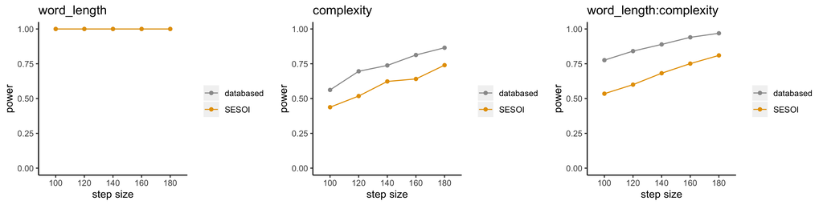

```r
# ------------------------------------------ #
# PLOT RESULTS
multiplotPower(R2power)
```

Finally, we need to transfer the plots and results into a decision regarding the sample size of our planned study. General guidance can be found in the accompanying tutorial paper. In this notebook, we will adapt a strategy resulting in > 80% power for all effects included in the model. To reach this threshold, we could either test 48 subjects each of whom reads 160 sentences. In a scenario where we only have resources for 30 subjects even 180 sentences would not be enough to power our study with > 80% power for all effects if we base our decision on the SESOI effect (as can be seen in the results of the R2power simulation). Moreover, we could run more simulations for even more combinations and base our decision on them. Repeating this process with different combinations (e.g. different R2levels) enables an extensive overview of power and the factors that influence it, which can be especially useful in cases in which one of the random effects cannot be increased, i.e. a ceiling on the amount of participants or stimuli.

Continue with [Notebook 3](https://lkumle.github.io/power_notebooks/Scenario3_notebook.html) for starting a simulation-based power estimation from scratch.

### References

Bates, D., Maechler, M., Bolker, B., & Walker, S. (2014). Fitting Linear Mixed-Effects Models using lme4. Journal of Statistical Software, 67(1). https://doi.org/10.18637/jss.v067.i01

Green, P., & Macleod, C. J. (2016). SIMR: An R package for power analysis of generalized linear mixed models by simulation. Methods in Ecology and Evolution, 7(4), 493-498. https://doi.org/10.1111/2041-210X.12504

Kumle, L., Vo, M. L-H., & Draschkow, D. (2018). Mixedpower: a library for estimating simulation-based power for mixed models in R. https://doi.org/10.5281/zenodo.1341047

Kumle, L., Võ, M.LH. & Draschkow, D. Estimating power in (generalized) linear mixed models: An open introduction and tutorial in R. Behav Res (2021). https://doi.org/10.3758/s13428-021-01546-0

Yan, M., Zhou, W., Shu, H., Yusupu, R., Miao, D., Kruegel, A., & Kliegl, R. (2014). Eye movements guided by morphological structure: Evidence from the Uighur language. Cognition, 132(2), 181???215. https://doi.org/10.1016/j.cognition.2014.03.008